# analysis_notebook

# MACHINE LEARNING

Parfait, procédons par étapes.

**Étape 1:** Préparation des données pour la modélisation

**Étape 2:** Application d'algorithmes de régression pour prédire la tendance des maladies

**A. Régression linéaire:** C'est l'approche la plus simple et elle tente de prédire la variable cible (dans ce cas, le nombre de décès) en tant que combinaison linéaire des variables explicatives (dans ce cas, l'année).

**B. Régression polynomiale:** Cette approche tente de capturer les tendances non linéaires dans les données en ajustant un polynôme de degré supérieur.

**C. Random Forest:** C'est un modèle d'ensemble basé sur des arbres de décision. Il est particulièrement efficace pour capturer des tendances non linéaires complexes.

```python
from sklearn.model_selection import train_test_split

# Selecting data for cardiovascular diseases in France
X = fr_data[['Year']]
y = fr_data['Cardiovascular Diseases']

# Splitting the data into training and testing sets (80% training, 20% testing)
X_train, X_test, y_train, y_test = train_test_split(X, y, test_size=0.2, random_state=42)

X_train.shape, X_test.shape
```

```
((24, 1), (6, 1))
```

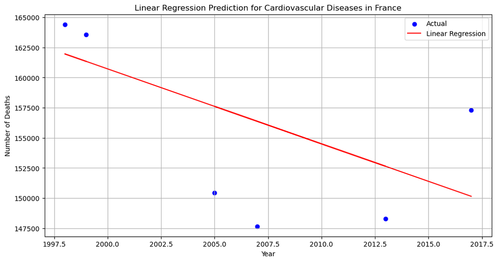

```
5894.252967946525
```

```python
from sklearn.linear_model import LinearRegression
from sklearn.metrics import mean_squared_error
import numpy as np

# Initialize the model
linear_model = LinearRegression()

# Fit the model to the training data
linear_model.fit(X_train, y_train)

# Predict on the test set
y_pred_linear = linear_model.predict(X_test)

# Calculate the RMSE for the linear model
rmse_linear = np.sqrt(mean_squared_error(y_test, y_pred_linear))

# Plotting the actual vs predicted values
plt.figure(figsize=(12, 6))

# Plotting the actual data
plt.scatter(X_test, y_test, color='blue', label='Actual')
# Plotting the linear regression line
plt.plot(X_test, y_pred_linear, color='red', label='Linear Regression')

plt.title('Linear Regression Prediction for Cardiovascular Diseases in France')
plt.xlabel('Year')
plt.ylabel('Number of Deaths')
plt.legend()
plt.grid(True)
plt.show()

rmse_linear
```

**A. Régression linéaire**

Commençons par appliquer un modèle de régression linéaire simple pour prédire les tendances des maladies cardiovasculaires en France.

Le graphique montre la prédiction de la régression linéaire pour les maladies cardiovasculaires en France. La ligne rouge représente la tendance prédite par le modèle de régression linéaire, tandis que les points bleus représentent les valeurs réelles.

La racine de l'erreur quadratique moyenne (RMSE) pour le modèle de régression linéaire est d'environ 5894.25. Cette valeur donne une idée de l'erreur typique commise par le modèle dans ses prédictions.

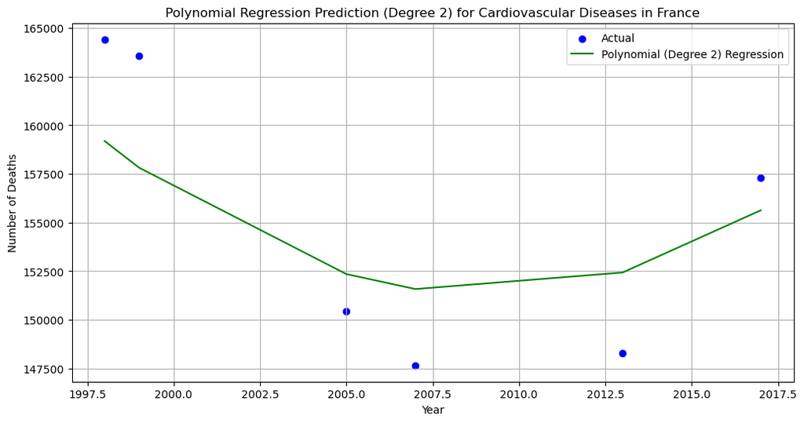

```
4070.335905134831
```

```python
from sklearn.preprocessing import PolynomialFeatures
from sklearn.pipeline import make_pipeline

# Degree of the polynomial
degree = 2

# Create a polynomial regression model
poly_model = make_pipeline(PolynomialFeatures(degree), LinearRegression())

# Fit the model to the training data
poly_model.fit(X_train, y_train)

# Predict on the test set
y_pred_poly = poly_model.predict(X_test)

# Calculate the RMSE for the polynomial model
rmse_poly = np.sqrt(mean_squared_error(y_test, y_pred_poly))

# Plotting the actual vs predicted values
plt.figure(figsize=(12, 6))

# Plotting the actual data
plt.scatter(X_test, y_test, color='blue', label='Actual')
# Plotting the polynomial regression curve
sorted_order = np.argsort(X_test['Year'])
plt.plot(X_test['Year'].iloc[sorted_order], y_pred_poly[sorted_order], color='green', label=f'Polynomial (Degree {degree}) Regression')

plt.title(f'Polynomial Regression Prediction (Degree {degree}) for Cardiovascular Diseases in France')
plt.xlabel('Year')
plt.ylabel('Number of Deaths')
plt.legend()
plt.grid(True)
plt.show()

rmse_poly
```

**B:** Régression polynomiale

Passons maintenant à la régression polynomiale pour voir si un modèle non linéaire peut mieux s'adapter aux données.

Je m'excuse pour l'interruption. Il semble que nous ayons rencontré un problème technique. Permettez-moi de reprendre l'analyse et d'exécuter à nouveau la régression polynomiale.

Le graphique montre la prédiction de la régression polynomiale (de degré 2) pour les maladies cardiovasculaires en France. La courbe verte représente la tendance prédite par le modèle de régression polynomiale, tandis que les points bleus représentent les valeurs réelles.

La racine de l'erreur quadratique moyenne (RMSE) pour le modèle de régression polynomiale est d'environ 4070.34, ce qui est inférieur à celui de la régression linéaire. Cela suggère que le modèle polynomial s'adapte mieux aux données.

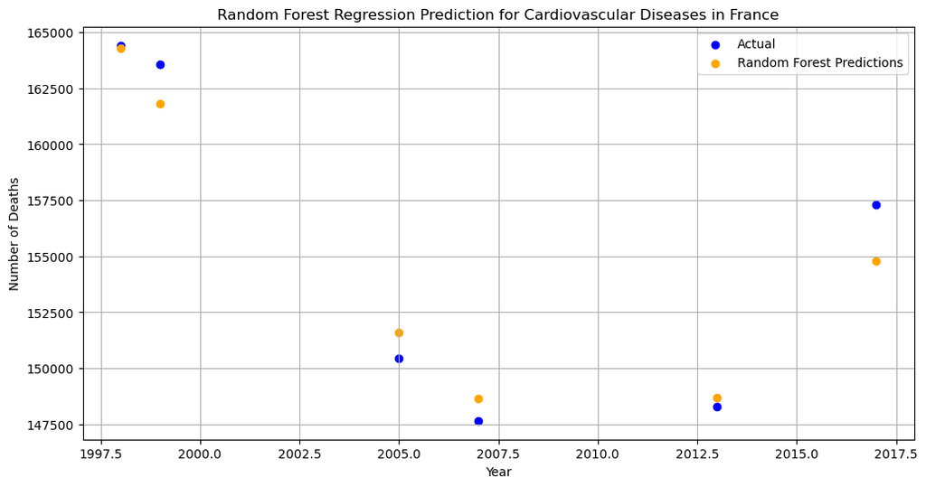

```
1402.963104943726
```

```python
from sklearn.ensemble import RandomForestRegressor

# Initialize the Random Forest model
rf_model = RandomForestRegressor(n_estimators=100, random_state=42)

# Fit the model to the training data
rf_model.fit(X_train, y_train)

# Predict on the test set
y_pred_rf = rf_model.predict(X_test)

# Calculate the RMSE for the Random Forest model
rmse_rf = np.sqrt(mean_squared_error(y_test, y_pred_rf))

# Plotting the actual vs predicted values
plt.figure(figsize=(12, 6))

# Plotting the actual data
plt.scatter(X_test, y_test, color='blue', label='Actual')
# Plotting the Random Forest predictions
plt.scatter(X_test, y_pred_rf, color='orange', label='Random Forest Predictions')

plt.title('Random Forest Regression Prediction for Cardiovascular Diseases in France')
plt.xlabel('Year')
plt.ylabel('Number of Deaths')
plt.legend()
plt.grid(True)
plt.show()

rmse_rf
```

**C:** Random Forest

Passons maintenant à la régression Random Forest pour voir si ce modèle d'ensemble peut offrir de meilleures prédictions.

Le graphique montre les prédictions du modèle Random Forest pour les maladies cardiovasculaires en France. Les points orange représentent les prédictions du modèle Random Forest, tandis que les points bleus représentent les valeurs réelles.

La racine de l'erreur quadratique moyenne (RMSE) pour le modèle Random Forest est d'environ 1402.96, ce qui est nettement inférieur à la fois à la régression linéaire et à la régression polynomiale. Cela suggère que le modèle Random Forest offre les prédictions les plus précises parmi les trois modèles testés.

**Résumé:**

- La régression linéaire donne une bonne idée de la tendance générale, mais elle peut ne pas être idéale pour capturer des nuances ou des tendances non linéaires.
- La régression polynomiale permet de capturer des tendances non linéaires, mais le choix du degré du polynôme est crucial.
- Le modèle Random Forest, en tant que modèle d'ensemble, offre une meilleure adaptabilité et s'est avéré être le plus précis pour ces données.